# ggraph and visualization

Maria Prokofieva

17/02/2021

```r
#install.packages(c("igraph","graphlayouts","ggraph","tidyverse", "statnet"))
#ggplot2 is part of tidyverse package

library(igraph)
library(statnet)
library(ggraph)
library(graphlayouts)
library(tidygraph)
```

## `ggraph` and `tidygraph` packages

While `igraph` and `statnet` packages are “classic” for working with networks, rather recent developments include `ggraph` and `tidygraph` packages:

-`ggraph` extension to ggplot2 for graph analysis

- `tidygraph` provides a way for `dplyr` to interact with graphs

let’s start with `ggraph`, but before let’s dig further into visualization.

## Effective network graphic design

What makes network graph layouts easier to understand and interpret?

- Minimize edge crossings.
- Maximize the symmetry of the layout of nodes.
- Minimize the variability of the edge lengths.
- Maximize the angle between edges when they cross or join nodes.
- Minimize the total space used for the network display

**Force-directed approach**: a flexible and powerful approach to automatic network layouts. It iteratively minimize the total energy in a network:

- connect nodes to have a spring-like attractive force, while simultaneously assigning repulsive forces to all pairs of nodes.
- The springs pull connected nodes closer to one another, but the repulsive forces push unconnected nodes away from each other.

## **The goal for any network graphic design should be to**

- **produce a figure that reveals the important or interesting information that is contained in the network data.**

### `ggraph`

R is FANTASTIC, but when visualizing networks, it lacks .. as time and effort are required to produce “nice” graphs

[figure not shown]

```r
g_got<-read_graph("https://raw.githubusercontent.com/schochastics/netViz/master/data/GoT/gotS1.graphml", format="graphml")

plot(g_got)
```

Does not look nice…

While in other visualization aspects R has a “winner” - `ggplot2` packages.

`ggraph` marries the `ggplot2` winning approach to the world of networks:

`ggraph`=`ggplot2 of networks`

We are also going to use `graphlayouts` package, which introduces additional useful layout algorithms to R.

`ggraph` uses the same underlying principles of the grammar of graphics. So, if you are familiar with them, you can skip the next section!

**Grammar of graphics**: a framework which follows a layered approach to describe and construct visualizations or graphics in a structured manner.

[This link](http://vita.had.co.nz/papers/layered-grammar.html) provides a more in-depth explanation of the grammar of graphics

Let’s have a brief look at out graph:

`autograph()`: quickly shows an overview of your network data.

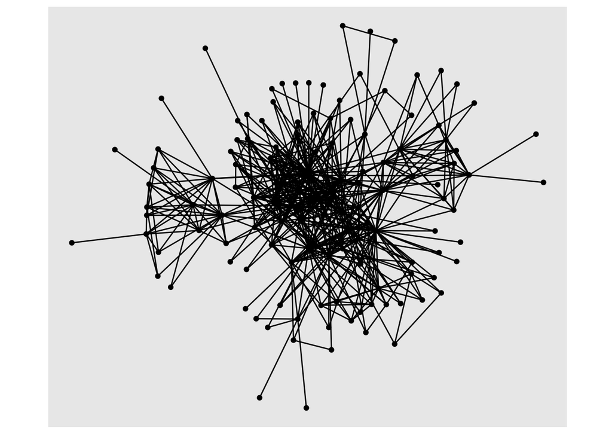

```r
autograph(g_got)
```

`ggraph` works with layers, where each layer adds a new feature to the plot and builds the final grapg step-by-step.

[figure not shown]

```r
got_palette <- c("#1A5878", "#C44237", "#AD8941", "#E99093", "#50594B")

ggraph(g_got,layout = "stress")+
  geom_edge_link0(aes(edge_width = Weight),edge_colour = "grey66")+
  geom_node_point(aes(fill = clu,size = size),shape=21)+
  geom_node_text(aes(filter = size >= 26, label = name),family="serif")+
  scale_fill_manual(values = got_palette)+
  scale_edge_width(range = c(0.2,3))+
  scale_size(range = c(1,6))+
  theme_graph()+
  theme(legend.position = "none")
```

Let’s have a closer look:

**Layout**: calculates a layout.